# EED-Stress results

Andrew Mertens

2024-03-24

## Results interpretations

Nothing is significant after correcting for multiple comparisons, so weak to no association between EED and stress outcome

Looks like Alpha-1 antitrypsan has the strongest associations with stress - specifically cortisol and salivary amalyase, but in opposite directions. I think cortisol and amalyase should both increase with stress, so interesting and hard to interpret finding. Ask Audrie, but could be random chance.

## Figures

### Consort figure

(to add)

### Heatmaps - adjusted analyses

Primary figures To do: scale point estimates, and add figure legends

### Figure 1 -Heatmap of adjusted association’s direction and significance for year 1 measurements

Cells are colored by the direction and P-value significance for each EED exposure and stress outcome combination. Printed in each cell is the point estimate from adjusted regression models. Each row is a specific stress outcome and each column is an EED exposure.

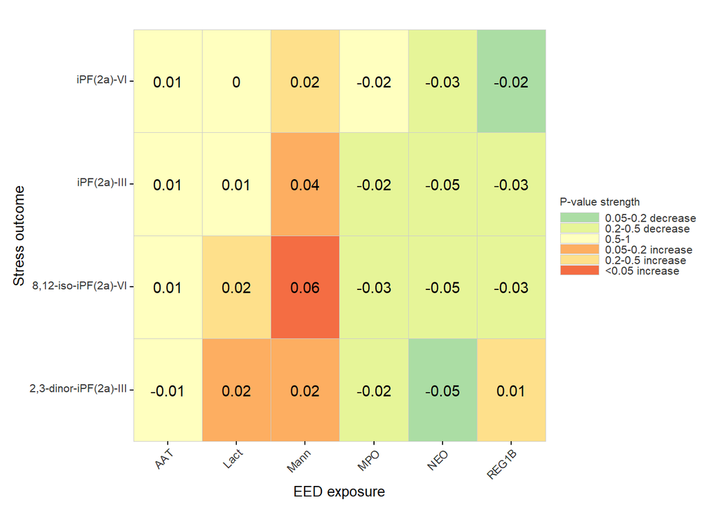

### Figure 2 -Heatmap of adjusted association’s direction and significance for year 2 measurements

Cells are colored by the direction and P-value significance for each EED exposure and stress outcome combination. Printed in each cell is the point estimate from adjusted regression models. Each row is a specific stress outcome and each column is an EED exposure.

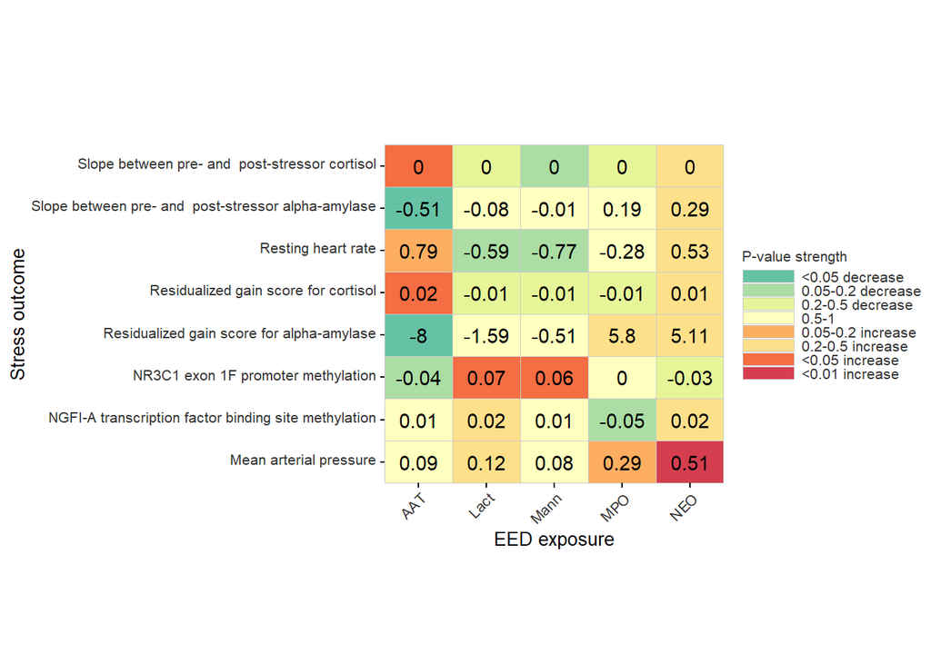

### Heatmaps - unadjusted analyses

-supplimentary figures

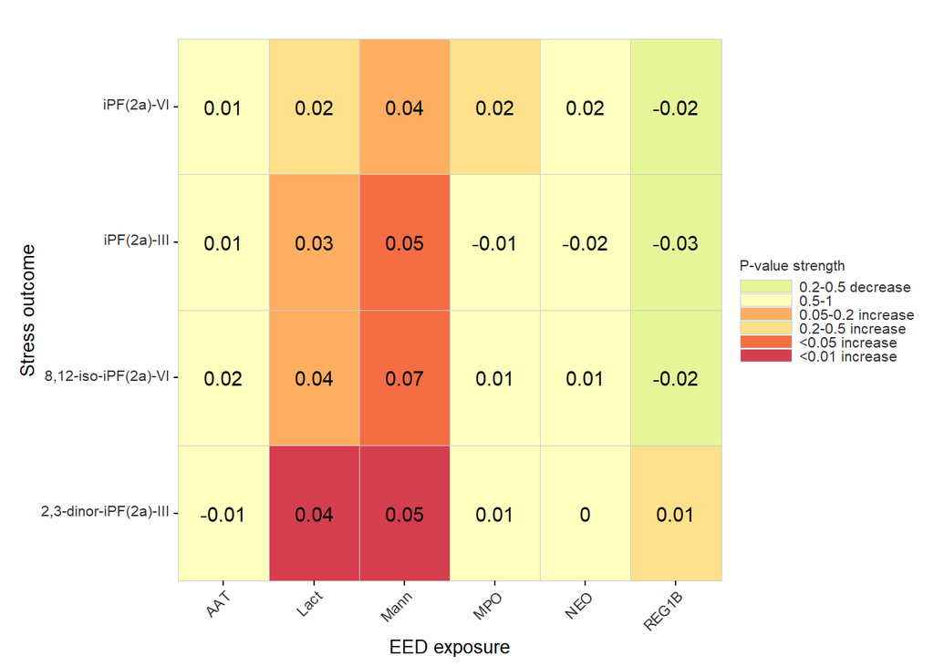

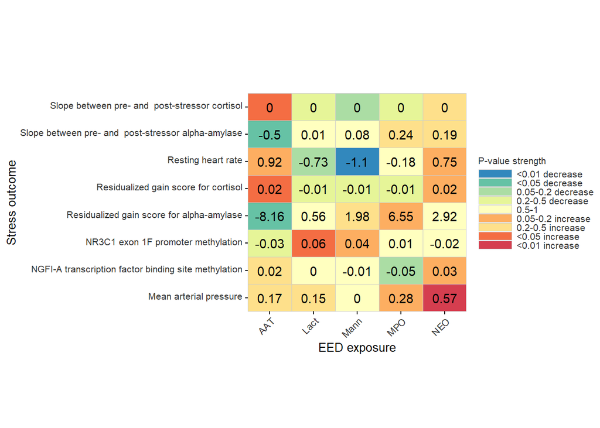

### Forest plots

(adjusted results only) To do: format labels

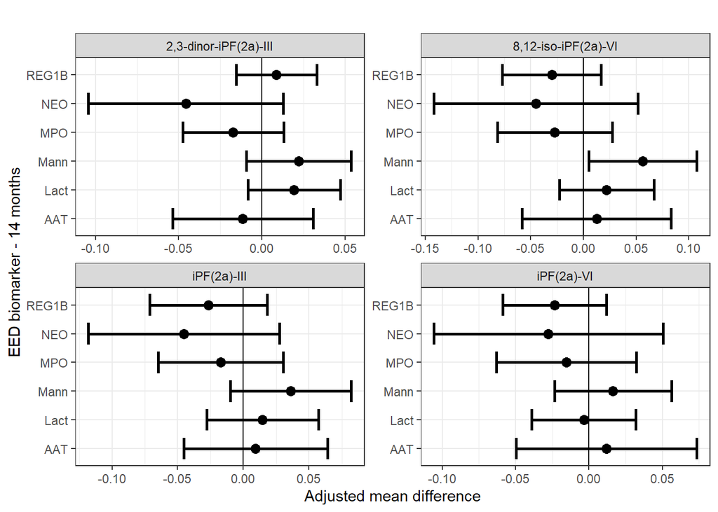

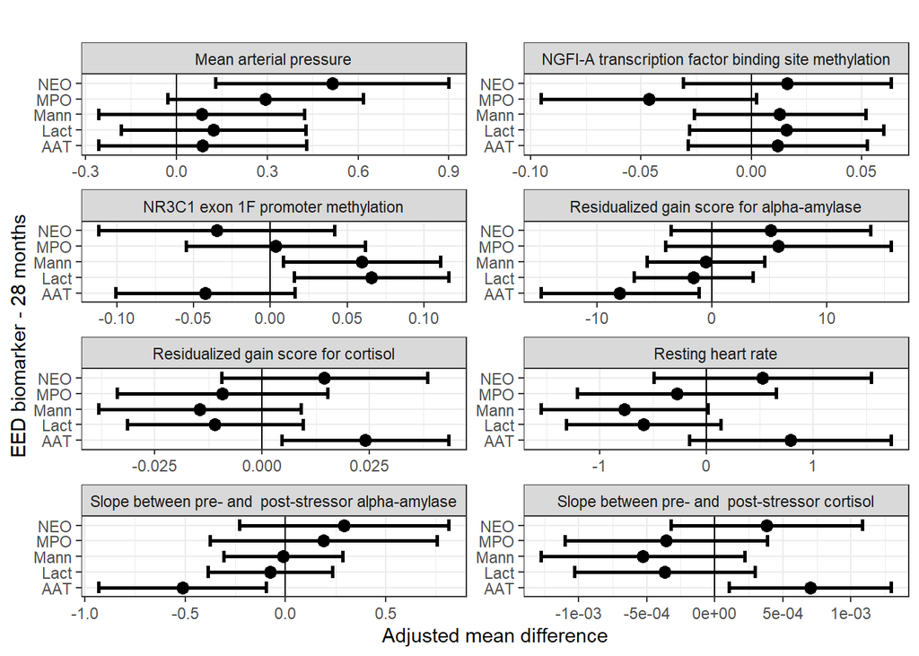

### Spline plots

Supplementary plots: to add for key significant relationships

## Tables

-Note I’m splitting the tables by domain of stress outcome (consistent with prior stress papers from this study)

### EED biomarker adjusted associations with year-1 oxidative stress measures

Biomarkers measured at child age 14 months

| EED exposure | Stress outcome | Meas. unit | Estimate | P-value | FDR-corrected P-value |
| --- | --- | --- | --- | --- | --- |
| AAT | iPF(2a)-III | ng/mg creatinine | 0.009 (-0.045, 0.064) | 0.7376 | 0.7696733 |
| AAT | 2,3-dinor-iPF(2a)-III | ng/mg creatinine | -0.012 (-0.054, 0.031) | 0.5895 | 0.7074301 |
| AAT | iPF(2a)-VI | ng/mg creatinine | 0.012 (-0.050, 0.074) | 0.7043 | 0.7696733 |
| AAT | 8,12-iso-iPF(2a)-VI | ng/mg creatinine | 0.012 (-0.058, 0.083) | 0.7300 | 0.7696733 |
| MPO | iPF(2a)-III | ng/mg creatinine | -0.017 (-0.065, 0.030) | 0.4756 | 0.6664969 |
| MPO | 2,3-dinor-iPF(2a)-III | ng/mg creatinine | -0.017 (-0.048, 0.013) | 0.2626 | 0.6303269 |
| MPO | iPF(2a)-VI | ng/mg creatinine | -0.015 (-0.063, 0.032) | 0.5276 | 0.6664969 |
| MPO | 8,12-iso-iPF(2a)-VI | ng/mg creatinine | -0.027 (-0.082, 0.027) | 0.3265 | 0.6664969 |
| NEO | iPF(2a)-III | ng/mg creatinine | -0.045 (-0.118, 0.027) | 0.2215 | 0.6303269 |
| NEO | 2,3-dinor-iPF(2a)-III | ng/mg creatinine | -0.046 (-0.104, 0.013) | 0.1262 | 0.6303269 |
| NEO | iPF(2a)-VI | ng/mg creatinine | -0.028 (-0.106, 0.050) | 0.4870 | 0.6664969 |
| NEO | 8,12-iso-iPF(2a)-VI | ng/mg creatinine | -0.045 (-0.142, 0.052) | 0.3615 | 0.6664969 |
| Lact | iPF(2a)-III | ng/mg creatinine | 0.015 (-0.028, 0.057) | 0.5019 | 0.6664969 |
| Lact | 2,3-dinor-iPF(2a)-III | ng/mg creatinine | 0.019 (-0.009, 0.047) | 0.1760 | 0.6303269 |
| Lact | iPF(2a)-VI | ng/mg creatinine | -0.004 (-0.039, 0.032) | 0.8418 | 0.8418374 |
| Lact | 8,12-iso-iPF(2a)-VI | ng/mg creatinine | 0.022 (-0.023, 0.067) | 0.3336 | 0.6664969 |
| Mann | iPF(2a)-III | ng/mg creatinine | 0.036 (-0.010, 0.082) | 0.1231 | 0.6303269 |
| Mann | 2,3-dinor-iPF(2a)-III | ng/mg creatinine | 0.022 (-0.009, 0.054) | 0.1689 | 0.6303269 |
| Mann | iPF(2a)-VI | ng/mg creatinine | 0.016 (-0.023, 0.056) | 0.4206 | 0.6664969 |
| Mann | 8,12-iso-iPF(2a)-VI | ng/mg creatinine | 0.056 (0.005, 0.108) | 0.0313 | 0.6303269 |
| REG1B | iPF(2a)-III | ng/mg creatinine | -0.027 (-0.071, 0.018) | 0.2433 | 0.6303269 |
| REG1B | 2,3-dinor-iPF(2a)-III | ng/mg creatinine | 0.009 (-0.016, 0.033) | 0.4825 | 0.6664969 |
| REG1B | iPF(2a)-VI | ng/mg creatinine | -0.023 (-0.059, 0.012) | 0.1957 | 0.6303269 |
| REG1B | 8,12-iso-iPF(2a)-VI | ng/mg creatinine | -0.030 (-0.077, 0.017) | 0.2105 | 0.6303269 |

### EED biomarker adjusted associations with year-2 sympathetic adrenomedullary axis measures

| EED exposure | Stress outcome | Meas. unit | Estimate | P-value | FDR-corrected P-value |
| --- | --- | --- | --- | --- | --- |
| AAT | Mean arterial pressure | mmHg | 0.086 (-0.257, 0.429) | 0.6224 | 0.6819064 |
| AAT | Resting heart rate | bpm | 0.787 (-0.157, 1.732) | 0.1023 | 0.3720139 |
| AAT | Slope between pre- and post-stressor alpha-amylase | U/ml/min | -0.513 (-0.931, -0.096) | 0.0159 | 0.1305711 |
| AAT | Residualized gain score for alpha-amylase | U/ml | -7.998 (-14.856, -1.139) | 0.0223 | 0.1305711 |
| MPO | Mean arterial pressure | mmHg | 0.294 (-0.030, 0.617) | 0.0749 | 0.2997172 |
| MPO | Resting heart rate | bpm | -0.277 (-1.210, 0.657) | 0.5612 | 0.6609979 |
| MPO | Slope between pre- and post-stressor alpha-amylase | U/ml/min | 0.189 (-0.375, 0.754) | 0.5110 | 0.6609979 |
| MPO | Residualized gain score for alpha-amylase | U/ml | 5.796 (-4.033, 15.624) | 0.2478 | 0.5332721 |
| NEO | Mean arterial pressure | mmHg | 0.515 (0.130, 0.900) | 0.0088 | 0.1305711 |
| NEO | Resting heart rate | bpm | 0.527 (-0.493, 1.546) | 0.3113 | 0.5413121 |
| NEO | Slope between pre- and post-stressor alpha-amylase | U/ml/min | 0.292 (-0.231, 0.814) | 0.2737 | 0.5332721 |
| NEO | Residualized gain score for alpha-amylase | U/ml | 5.113 (-3.576, 13.801) | 0.2488 | 0.5332721 |
| Lact | Mean arterial pressure | mmHg | 0.122 (-0.183, 0.427) | 0.4340 | 0.6609979 |
| Lact | Resting heart rate | bpm | -0.588 (-1.313, 0.137) | 0.1120 | 0.3734191 |
| Lact | Slope between pre- and post-stressor alpha-amylase | U/ml/min | -0.077 (-0.388, 0.234) | 0.6281 | 0.6819064 |
| Lact | Residualized gain score for alpha-amylase | U/ml | -1.592 (-6.769, 3.585) | 0.5467 | 0.6609979 |
| Mann | Mean arterial pressure | mmHg | 0.083 (-0.257, 0.424) | 0.6308 | 0.6819064 |
| Mann | Resting heart rate | bpm | -0.768 (-1.548, 0.013) | 0.0538 | 0.2689487 |
| Mann | Slope between pre- and post-stressor alpha-amylase | U/ml/min | -0.011 (-0.307, 0.286) | 0.9442 | 0.9441557 |
| Mann | Residualized gain score for alpha-amylase | U/ml | -0.508 (-5.628, 4.612) | 0.8458 | 0.8902763 |

### EED biomarker adjusted associations with year-2 hypothalamic-pituitary-adrenal axis measures

| EED exposure | Stress outcome | Meas. unit | Estimate | P-value | FDR-corrected P-value |
| --- | --- | --- | --- | --- | --- |
| AAT | NR3C1 exon 1F promoter methylation |  | -0.042 (-0.101, 0.016) | 0.1553 | 0.4725492 |
| AAT | NGFI-A transcription factor binding site methylation |  | 0.012 (-0.029, 0.053) | 0.5618 | 0.6609979 |
| AAT | Slope between pre- and post-stressor cortisol | μg/dl/min | 0.001 (0.000, 0.001) | 0.0213 | 0.1305711 |
| AAT | Residualized gain score for cortisol | μg/dl | 0.024 (0.005, 0.043) | 0.0157 | 0.1305711 |
| MPO | NR3C1 exon 1F promoter methylation |  | 0.003 (-0.055, 0.062) | 0.9086 | 0.9319487 |
| MPO | NGFI-A transcription factor binding site methylation |  | -0.047 (-0.095, 0.002) | 0.0619 | 0.2752044 |
| MPO | Slope between pre- and post-stressor cortisol | μg/dl/min | -0.000 (-0.001, 0.000) | 0.3464 | 0.5773537 |
| MPO | Residualized gain score for cortisol | μg/dl | -0.009 (-0.034, 0.015) | 0.4563 | 0.6609979 |
| NEO | NR3C1 exon 1F promoter methylation |  | -0.035 (-0.112, 0.042) | 0.3728 | 0.5964938 |
| NEO | NGFI-A transcription factor binding site methylation |  | 0.016 (-0.031, 0.063) | 0.4995 | 0.6609979 |
| NEO | Slope between pre- and post-stressor cortisol | μg/dl/min | 0.000 (-0.000, 0.001) | 0.2902 | 0.5332721 |
| NEO | Residualized gain score for cortisol | μg/dl | 0.014 (-0.009, 0.038) | 0.2348 | 0.5332721 |
| Lact | NR3C1 exon 1F promoter methylation |  | 0.066 (0.016, 0.116) | 0.0102 | 0.1305711 |
| Lact | NGFI-A transcription factor binding site methylation |  | 0.016 (-0.028, 0.060) | 0.4778 | 0.6609979 |
| Lact | Slope between pre- and post-stressor cortisol | μg/dl/min | -0.000 (-0.001, 0.000) | 0.2745 | 0.5332721 |
| Lact | Residualized gain score for cortisol | μg/dl | -0.011 (-0.031, 0.009) | 0.2933 | 0.5332721 |
| Mann | NR3C1 exon 1F promoter methylation |  | 0.060 (0.008, 0.111) | 0.0228 | 0.1305711 |
| Mann | NGFI-A transcription factor binding site methylation |  | 0.013 (-0.026, 0.052) | 0.5173 | 0.6609979 |
| Mann | Slope between pre- and post-stressor cortisol | μg/dl/min | -0.001 (-0.001, 0.000) | 0.1654 | 0.4725492 |
| Mann | Residualized gain score for cortisol | μg/dl | -0.015 (-0.038, 0.009) | 0.2273 | 0.5332721 |